# Project: Wrangle and Analyze Data

The objective of this project is to wrangle WeRateDogs ([@dog_rates](https://twitter.com/dog_rates?ref_src=twsrc%5Egoogle%7Ctwcamp%5Eserp%7Ctwgr%5Eauthor)) Twitter data to create an enriched clean dataset that can produce interesting and trustworthy analyses and visualizations.

*This notebook contains my code and technical processes. For a summary of the project, approach and outcomes, please see wrangle_report.pdf (technical descriptions) and act_report.pdf (business/public facing summary)*

- Gathering
- Assessment
- Cleaning
- Analysis and Visualizations
- Conclusions

## Gather Data

Import necessary packages:

```python
import requests
import json
import tweepy
from tweepy import OAuthHandler
from timeit import default_timer as timer
import numpy as np
import pandas as pd
import matplotlib.pyplot as plt
import seaborn as sns
%matplotlib inline
```

1. Read twitter-archive-enhanced.csv file into a pandas dataframe

```python
#Read in twitter-archive .csv file
df_archive = pd.read_csv('twitter-archive-enhanced.csv')
df_archive.head()
```

|  | tweet_id | in_reply_to_status_id | in_reply_to_user_id | timestamp | source | text | retweeted_status_id | retweeted_status_user_id | retweeted_status_timestamp | expanded_urls | rating_numerator | rating_denominator | name | doggo | floofer | pupper | puppo |
| --- | --- | --- | --- | --- | --- | --- | --- | --- | --- | --- | --- | --- | --- | --- | --- | --- | --- |
| 0 | 892420643555336193 | NaN | NaN | 2017-08-01 16:23:56 +0000 | <a href="http://twitter.com/download/iphone" r... | This is Phineas. He's a mystical boy. Only eve... | NaN | NaN | NaN | https://twitter.com/dog_rates/status/892420643... | 13 | 10 | Phineas | None | None | None | None |
| 1 | 892177421306343426 | NaN | NaN | 2017-08-01 00:17:27 +0000 | <a href="http://twitter.com/download/iphone" r... | This is Tilly. She's just checking pup on you.... | NaN | NaN | NaN | https://twitter.com/dog_rates/status/892177421... | 13 | 10 | Tilly | None | None | None | None |
| 2 | 891815181378084864 | NaN | NaN | 2017-07-31 00:18:03 +0000 | <a href="http://twitter.com/download/iphone" r... | This is Archie. He is a rare Norwegian Pouncin... | NaN | NaN | NaN | https://twitter.com/dog_rates/status/891815181... | 12 | 10 | Archie | None | None | None | None |
| 3 | 891689557279858688 | NaN | NaN | 2017-07-30 15:58:51 +0000 | <a href="http://twitter.com/download/iphone" r... | This is Darla. She commenced a snooze mid meal... | NaN | NaN | NaN | https://twitter.com/dog_rates/status/891689557... | 13 | 10 | Darla | None | None | None | None |
| 4 | 891327558926688256 | NaN | NaN | 2017-07-29 16:00:24 +0000 | <a href="http://twitter.com/download/iphone" r... | This is Franklin. He would like you to stop ca... | NaN | NaN | NaN | https://twitter.com/dog_rates/status/891327558... | 12 | 10 | Franklin | None | None | None | None |

1. Use Requests library to programatically download the image-predictions.tsv file from Udacity servers

```python
url = 'https://d17h27t6h515a5.cloudfront.net/topher/2017/August/599fd2ad_image-predictions/image-predictions.tsv'

#get the content from the url
response = requests.get(url)

#write the content to a file
with open ('image-predictions.tsv',mode='wb') as file:
    file.write(response.content)

#open file as a pandas dataframe
df_predict = pd.read_csv('image-predictions.tsv',sep='\t')
df_predict.head()
```

|  | tweet_id | jpg_url | img_num | p1 | p1_conf | p1_dog | p2 | p2_conf | p2_dog | p3 | p3_conf | p3_dog |
| --- | --- | --- | --- | --- | --- | --- | --- | --- | --- | --- | --- | --- |
| 0 | 666020888022790149 | https://pbs.twimg.com/media/CT4udn0WwAA0aMy.jpg | 1 | Welsh_springer_spaniel | 0.465074 | True | collie | 0.156665 | True | Shetland_sheepdog | 0.061428 | True |
| 1 | 666029285002620928 | https://pbs.twimg.com/media/CT42GRgUYAA5iDo.jpg | 1 | redbone | 0.506826 | True | miniature_pinscher | 0.074192 | True | Rhodesian_ridgeback | 0.072010 | True |
| 2 | 666033412701032449 | https://pbs.twimg.com/media/CT4521TWwAEvMyu.jpg | 1 | German_shepherd | 0.596461 | True | malinois | 0.138584 | True | bloodhound | 0.116197 | True |
| 3 | 666044226329800704 | https://pbs.twimg.com/media/CT5Dr8HUEAA-lEu.jpg | 1 | Rhodesian_ridgeback | 0.408143 | True | redbone | 0.360687 | True | miniature_pinscher | 0.222752 | True |
| 4 | 666049248165822465 | https://pbs.twimg.com/media/CT5IQmsXIAAKY4A.jpg | 1 | miniature_pinscher | 0.560311 | True | Rottweiler | 0.243682 | True | Doberman | 0.154629 | True |

1. Use tweepy API to extract JSON file with retweets, favorites and other interesting data.

```python
#Load Twitter API Keys
with open ('twitter_api_credentials','r') as file:
        consumer_key = file.readline()
        consumer_secret = file.readline()
        access_token = file.readline()
        access_secret = file.readline()

auth = tweepy.OAuthHandler(consumer_key,consumer_secret)
auth.set_access_token(access_token,access_secret)

api = tweepy.API(auth, wait_on_rate_limit=True)

tweet_ids = df_archive.tweet_id.values
len(tweet_ids)
```

```
2356
```

```python
#Query the Twitter API for JSON data for each tweet id present in the archives dataframe

count = 0
fails_dict = {}
start = timer()


with open ('tweet_json.txt','w') as file: #the file we want to save the tweet json data to
    for tweet_id in tweet_ids: #loop for each tweet in our .csv file
        count += 1
        print(str(count) + ": " + str(tweet_id))
        try: #try and get the json details for each tweet id in extended mode. If it works, print success.
            tweet = api.get_status(tweet_id,tweet_mode='extended') #this line is calling the API
            print("Success")
            json.dump(tweet._json, file) #if it works, add the content to the tweet_json.txt file specified as 'file'
            file.write('\n') #add a new blank line to the file
        except tweepy.TweepError as e: #if an API error occurs, print Fail and add the tweet id to our fails dictionary
            print("Fail")
            fails_dict[tweet_id] = e
            pass #continue to loop through for the next tweet_id
end = timer()
print(end-start)
print(fails_dict)
```

*Tweet Data has been successfully written to tweet_json.txt. Next step is to extract what we want from that JSON and put it into a Pandas dataframe. The tweets that were deleted will be missing data and can be dropped from the archive dataset later on when we merge tables*

```python
#JSON to python dictionary - read the output file previously generated and append the dictionaries to a list called json_data

df_tweet = pd.DataFrame(columns=['tweet_id','retweet_count','favorite_count'])

with open('tweet_json.txt','r') as file:
    for line in file:
        data = json.loads(line) #this line is key for turning json file structure into pandas dictionaries
        tweet_id = data['id']
        retweet_count = data['retweet_count']
        favorite_count = data['favorite_count']
        df_tweet = df_tweet.append(pd.DataFrame([[tweet_id,retweet_count,favorite_count]],columns=['tweet_id','retweet_count','favorite_count']))
```

```python
df_tweet.head()
```

|  | tweet_id | retweet_count | favorite_count |
| --- | --- | --- | --- |
| 0 | 892420643555336193 | 7447 | 35288 |
| 0 | 892177421306343426 | 5532 | 30529 |
| 0 | 891815181378084864 | 3660 | 22981 |
| 0 | 891689557279858688 | 7618 | 38570 |
| 0 | 891327558926688256 | 8213 | 36856 |

*Trying to convert a .json file into a pandas dataframe. However, some of the dictionary keys that we want, such as the image URLs, are nested within other dictionaries. Use pd.json_normalize to flatten those dictionaries so that each key can be its own df column. Then we can merge this with the df_tweet containing the top layer keys (i.e. favorite count and retweet count)*

Extracting the nested dictionary keys within 'entities'

```python
all_data = []
with open('tweet_json.txt','r') as file:
    for line in file:
        eachDict = json.loads(line)
        #check if entities has a key called media
        if eachDict['entities'].get('media'):
            all_data.append(eachDict)
```

```python
type(all_data)
```

```
list
```

Create the flattened df containing all entities keys as columns

```python
from pandas.io.json import json_normalize

#['entities','media'] from the 'entities' key, flatten the 'media' dictionary
entities_df = json_normalize(all_data,[['entities','media']], ['id'], record_prefix='entities_')
entities_df['id'] = entities_df['id'].astype('object')
entities_df.head()
```

|  | entities_display_url | entities_expanded_url | entities_id | entities_id_str | entities_indices | entities_media_url | entities_media_url_https | entities_sizes | entities_source_status_id | entities_source_status_id_str | entities_source_user_id | entities_source_user_id_str | entities_type | entities_url | id |
| --- | --- | --- | --- | --- | --- | --- | --- | --- | --- | --- | --- | --- | --- | --- | --- |
| 0 | pic.twitter.com/MgUWQ76dJU | https://twitter.com/dog_rates/status/892420643... | 892420639486877696 | 892420639486877696 | [86, 109] | http://pbs.twimg.com/media/DGKD1-bXoAAIAUK.jpg | https://pbs.twimg.com/media/DGKD1-bXoAAIAUK.jpg | {'thumb': {'w': 150, 'h': 150, 'resize': 'crop... | NaN | NaN | NaN | NaN | photo | https://t.co/MgUWQ76dJU | 892420643555336193 |
| 1 | pic.twitter.com/0Xxu71qeIV | https://twitter.com/dog_rates/status/892177421... | 892177413194625024 | 892177413194625024 | [139, 162] | http://pbs.twimg.com/media/DGGmoV4XsAAUL6n.jpg | https://pbs.twimg.com/media/DGGmoV4XsAAUL6n.jpg | {'thumb': {'w': 150, 'h': 150, 'resize': 'crop... | NaN | NaN | NaN | NaN | photo | https://t.co/0Xxu71qeIV | 892177421306343426 |
| 2 | pic.twitter.com/wUnZnhtVJB | https://twitter.com/dog_rates/status/891815181... | 891815175371796480 | 891815175371796480 | [122, 145] | http://pbs.twimg.com/media/DGBdLU1WsAANxJ9.jpg | https://pbs.twimg.com/media/DGBdLU1WsAANxJ9.jpg | {'thumb': {'w': 150, 'h': 150, 'resize': 'crop... | NaN | NaN | NaN | NaN | photo | https://t.co/wUnZnhtVJB | 891815181378084864 |
| 3 | pic.twitter.com/tD36da7qLQ | https://twitter.com/dog_rates/status/891689557... | 891689552724799489 | 891689552724799489 | [80, 103] | http://pbs.twimg.com/media/DF_q7IAWsAEuuN8.jpg | https://pbs.twimg.com/media/DF_q7IAWsAEuuN8.jpg | {'thumb': {'w': 150, 'h': 150, 'resize': 'crop... | NaN | NaN | NaN | NaN | photo | https://t.co/tD36da7qLQ | 891689557279858688 |
| 4 | pic.twitter.com/AtUZn91f7f | https://twitter.com/dog_rates/status/891327558... | 891327551943041024 | 891327551943041024 | [139, 162] | http://pbs.twimg.com/media/DF6hr6AVYAAZ8G8.jpg | https://pbs.twimg.com/media/DF6hr6AVYAAZ8G8.jpg | {'medium': {'w': 720, 'h': 540, 'resize': 'fit... | NaN | NaN | NaN | NaN | photo | https://t.co/AtUZn91f7f | 891327558926688256 |

Merge the two dataframes together and filter for only the columns of interest

```python
df_full = df_tweet.merge(entities_df,left_on='tweet_id',right_on='id')
```

```python
#pick the columns from df_full that we want to include in our dataset
df_api = df_full[['tweet_id','retweet_count','favorite_count','entities_media_url']]
df_api.head()
```

|  | tweet_id | retweet_count | favorite_count | entities_media_url |
| --- | --- | --- | --- | --- |
| 0 | 892420643555336193 | 7447 | 35288 | http://pbs.twimg.com/media/DGKD1-bXoAAIAUK.jpg |
| 1 | 892177421306343426 | 5532 | 30529 | http://pbs.twimg.com/media/DGGmoV4XsAAUL6n.jpg |
| 2 | 891815181378084864 | 3660 | 22981 | http://pbs.twimg.com/media/DGBdLU1WsAANxJ9.jpg |
| 3 | 891689557279858688 | 7618 | 38570 | http://pbs.twimg.com/media/DF_q7IAWsAEuuN8.jpg |
| 4 | 891327558926688256 | 8213 | 36856 | http://pbs.twimg.com/media/DF6hr6AVYAAZ8G8.jpg |

## Assess Data

Identify data quality and data tidiness issues in each of the three data sources gathered. A summary of issues is in the last cell of this section. These were determined through:

- Visual Assessment: Conducted a review of data files in Google Sheets, including values and filters
- Programmatic Assessment: Conducted using pandas functionalities as documented below

```python
pd.set_option("display.max_colwidth", -1)
df_archive.head(20)
```

|  | tweet_id | in_reply_to_status_id | in_reply_to_user_id | timestamp | source | text | retweeted_status_id | retweeted_status_user_id | retweeted_status_timestamp | expanded_urls | rating_numerator | rating_denominator | name | doggo | floofer | pupper | puppo |
| --- | --- | --- | --- | --- | --- | --- | --- | --- | --- | --- | --- | --- | --- | --- | --- | --- | --- |
| 0 | 892420643555336193 | NaN | NaN | 2017-08-01 16:23:56 +0000 | <a href="http://twitter.com/download/iphone" rel="nofollow">Twitter for iPhone</a> | This is Phineas. He's a mystical boy. Only ever appears in the hole of a donut. 13/10 https://t.co/MgUWQ76dJU | NaN | NaN | NaN | https://twitter.com/dog_rates/status/892420643555336193/photo/1 | 13 | 10 | Phineas | None | None | None | None |
| 1 | 892177421306343426 | NaN | NaN | 2017-08-01 00:17:27 +0000 | <a href="http://twitter.com/download/iphone" rel="nofollow">Twitter for iPhone</a> | This is Tilly. She's just checking pup on you. Hopes you're doing ok. If not, she's available for pats, snugs, boops, the whole bit. 13/10 https://t.co/0Xxu71qeIV | NaN | NaN | NaN | https://twitter.com/dog_rates/status/892177421306343426/photo/1 | 13 | 10 | Tilly | None | None | None | None |
| 2 | 891815181378084864 | NaN | NaN | 2017-07-31 00:18:03 +0000 | <a href="http://twitter.com/download/iphone" rel="nofollow">Twitter for iPhone</a> | This is Archie. He is a rare Norwegian Pouncing Corgo. Lives in the tall grass. You never know when one may strike. 12/10 https://t.co/wUnZnhtVJB | NaN | NaN | NaN | https://twitter.com/dog_rates/status/891815181378084864/photo/1 | 12 | 10 | Archie | None | None | None | None |
| 3 | 891689557279858688 | NaN | NaN | 2017-07-30 15:58:51 +0000 | <a href="http://twitter.com/download/iphone" rel="nofollow">Twitter for iPhone</a> | This is Darla. She commenced a snooze mid meal. 13/10 happens to the best of us https://t.co/tD36da7qLQ | NaN | NaN | NaN | https://twitter.com/dog_rates/status/891689557279858688/photo/1 | 13 | 10 | Darla | None | None | None | None |
| 4 | 891327558926688256 | NaN | NaN | 2017-07-29 16:00:24 +0000 | <a href="http://twitter.com/download/iphone" rel="nofollow">Twitter for iPhone</a> | This is Franklin. He would like you to stop calling him "cute." He is a very fierce shark and should be respected as such. 12/10 #BarkWeek https://t.co/AtUZn91f7f | NaN | NaN | NaN | https://twitter.com/dog_rates/status/891327558926688256/photo/1,https://twitter.com/dog_rates/status/891327558926688256/photo/1 | 12 | 10 | Franklin | None | None | None | None |
| 5 | 891087950875897856 | NaN | NaN | 2017-07-29 00:08:17 +0000 | <a href="http://twitter.com/download/iphone" rel="nofollow">Twitter for iPhone</a> | Here we have a majestic great white breaching off South Africa's coast. Absolutely h*ckin breathtaking. 13/10 (IG: tucker_marlo) #BarkWeek https://t.co/kQ04fDDRmh | NaN | NaN | NaN | https://twitter.com/dog_rates/status/891087950875897856/photo/1 | 13 | 10 | None | None | None | None | None |
| 6 | 890971913173991426 | NaN | NaN | 2017-07-28 16:27:12 +0000 | <a href="http://twitter.com/download/iphone" rel="nofollow">Twitter for iPhone</a> | Meet Jax. He enjoys ice cream so much he gets nervous around it. 13/10 help Jax enjoy more things by clicking below\n\nhttps://t.co/Zr4hWfAs1H https://t.co/tVJBRMnhxl | NaN | NaN | NaN | https://gofundme.com/ydvmve-surgery-for-jax,https://twitter.com/dog_rates/status/890971913173991426/photo/1 | 13 | 10 | Jax | None | None | None | None |
| 7 | 890729181411237888 | NaN | NaN | 2017-07-28 00:22:40 +0000 | <a href="http://twitter.com/download/iphone" rel="nofollow">Twitter for iPhone</a> | When you watch your owner call another dog a good boy but then they turn back to you and say you're a great boy. 13/10 https://t.co/v0nONBcwxq | NaN | NaN | NaN | https://twitter.com/dog_rates/status/890729181411237888/photo/1,https://twitter.com/dog_rates/status/890729181411237888/photo/1 | 13 | 10 | None | None | None | None | None |
| 8 | 890609185150312448 | NaN | NaN | 2017-07-27 16:25:51 +0000 | <a href="http://twitter.com/download/iphone" rel="nofollow">Twitter for iPhone</a> | This is Zoey. She doesn't want to be one of the scary sharks. Just wants to be a snuggly pettable boatpet. 13/10 #BarkWeek https://t.co/9TwLuAGH0b | NaN | NaN | NaN | https://twitter.com/dog_rates/status/890609185150312448/photo/1 | 13 | 10 | Zoey | None | None | None | None |
| 9 | 890240255349198849 | NaN | NaN | 2017-07-26 15:59:51 +0000 | <a href="http://twitter.com/download/iphone" rel="nofollow">Twitter for iPhone</a> | This is Cassie. She is a college pup. Studying international doggo communication and stick theory. 14/10 so elegant much sophisticate https://t.co/t1bfwz5S2A | NaN | NaN | NaN | https://twitter.com/dog_rates/status/890240255349198849/photo/1 | 14 | 10 | Cassie | doggo | None | None | None |
| 10 | 890006608113172480 | NaN | NaN | 2017-07-26 00:31:25 +0000 | <a href="http://twitter.com/download/iphone" rel="nofollow">Twitter for iPhone</a> | This is Koda. He is a South Australian deckshark. Deceptively deadly. Frighteningly majestic. 13/10 would risk a petting #BarkWeek https://t.co/dVPW0B0Mme | NaN | NaN | NaN | https://twitter.com/dog_rates/status/890006608113172480/photo/1,https://twitter.com/dog_rates/status/890006608113172480/photo/1 | 13 | 10 | Koda | None | None | None | None |
| 11 | 889880896479866881 | NaN | NaN | 2017-07-25 16:11:53 +0000 | <a href="http://twitter.com/download/iphone" rel="nofollow">Twitter for iPhone</a> | This is Bruno. He is a service shark. Only gets out of the water to assist you. 13/10 terrifyingly good boy https://t.co/u1XPQMl29g | NaN | NaN | NaN | https://twitter.com/dog_rates/status/889880896479866881/photo/1 | 13 | 10 | Bruno | None | None | None | None |
| 12 | 889665388333682689 | NaN | NaN | 2017-07-25 01:55:32 +0000 | <a href="http://twitter.com/download/iphone" rel="nofollow">Twitter for iPhone</a> | Here's a puppo that seems to be on the fence about something haha no but seriously someone help her. 13/10 https://t.co/BxvuXk0UCm | NaN | NaN | NaN | https://twitter.com/dog_rates/status/889665388333682689/photo/1 | 13 | 10 | None | None | None | None | puppo |
| 13 | 889638837579907072 | NaN | NaN | 2017-07-25 00:10:02 +0000 | <a href="http://twitter.com/download/iphone" rel="nofollow">Twitter for iPhone</a> | This is Ted. He does his best. Sometimes that's not enough. But it's ok. 12/10 would assist https://t.co/f8dEDcrKSR | NaN | NaN | NaN | https://twitter.com/dog_rates/status/889638837579907072/photo/1,https://twitter.com/dog_rates/status/889638837579907072/photo/1 | 12 | 10 | Ted | None | None | None | None |
| 14 | 889531135344209921 | NaN | NaN | 2017-07-24 17:02:04 +0000 | <a href="http://twitter.com/download/iphone" rel="nofollow">Twitter for iPhone</a> | This is Stuart. He's sporting his favorite fanny pack. Secretly filled with bones only. 13/10 puppared puppo #BarkWeek https://t.co/y70o6h3isq | NaN | NaN | NaN | https://twitter.com/dog_rates/status/889531135344209921/photo/1 | 13 | 10 | Stuart | None | None | None | puppo |
| 15 | 889278841981685760 | NaN | NaN | 2017-07-24 00:19:32 +0000 | <a href="http://twitter.com/download/iphone" rel="nofollow">Twitter for iPhone</a> | This is Oliver. You're witnessing one of his many brutal attacks. Seems to be playing with his victim. 13/10 fr*ckin frightening #BarkWeek https://t.co/WpHvrQedPb | NaN | NaN | NaN | https://twitter.com/dog_rates/status/889278841981685760/video/1 | 13 | 10 | Oliver | None | None | None | None |
| 16 | 888917238123831296 | NaN | NaN | 2017-07-23 00:22:39 +0000 | <a href="http://twitter.com/download/iphone" rel="nofollow">Twitter for iPhone</a> | This is Jim. He found a fren. Taught him how to sit like the good boys. 12/10 for both https://t.co/chxruIOUJN | NaN | NaN | NaN | https://twitter.com/dog_rates/status/888917238123831296/photo/1 | 12 | 10 | Jim | None | None | None | None |
| 17 | 888804989199671297 | NaN | NaN | 2017-07-22 16:56:37 +0000 | <a href="http://twitter.com/download/iphone" rel="nofollow">Twitter for iPhone</a> | This is Zeke. He has a new stick. Very proud of it. Would like you to throw it for him without taking it. 13/10 would do my best https://t.co/HTQ77yNQ5K | NaN | NaN | NaN | https://twitter.com/dog_rates/status/888804989199671297/photo/1,https://twitter.com/dog_rates/status/888804989199671297/photo/1 | 13 | 10 | Zeke | None | None | None | None |
| 18 | 888554962724278272 | NaN | NaN | 2017-07-22 00:23:06 +0000 | <a href="http://twitter.com/download/iphone" rel="nofollow">Twitter for iPhone</a> | This is Ralphus. He's powering up. Attempting maximum borkdrive. 13/10 inspirational af https://t.co/YnYAFCTTiK | NaN | NaN | NaN | https://twitter.com/dog_rates/status/888554962724278272/photo/1,https://twitter.com/dog_rates/status/888554962724278272/photo/1,https://twitter.com/dog_rates/status/888554962724278272/photo/1,https://… | 13 | 10 | Ralphus | None | None | None | None |
| 19 | 888202515573088257 | NaN | NaN | 2017-07-21 01:02:36 +0000 | <a href="http://twitter.com/download/iphone" rel="nofollow">Twitter for iPhone</a> | RT @dog_rates: This is Canela. She attempted some fancy porch pics. They were unsuccessful. 13/10 someone help her https://t.co/cLyzpcUcMX | 8.874740e+17 | 4.196984e+09 | 2017-07-19 00:47:34 +0000 | https://twitter.com/dog_rates/status/887473957103951883/photo/1,https://twitter.com/dog_rates/status/887473957103951883/photo/1,https://twitter.com/dog_rates/status/887473957103951883/photo/1,https://… | 13 | 10 | Canela | None | None | None | None |

```python
df_archive.info()
```

```
<class 'pandas.core.frame.DataFrame'>
RangeIndex: 2356 entries, 0 to 2355
Data columns (total 17 columns):
tweet_id                      2356 non-null int64
in_reply_to_status_id         78 non-null float64
in_reply_to_user_id           78 non-null float64
timestamp                     2356 non-null object
source                        2356 non-null object
text                          2356 non-null object
retweeted_status_id           181 non-null float64
retweeted_status_user_id      181 non-null float64
retweeted_status_timestamp    181 non-null object
expanded_urls                 2297 non-null object
rating_numerator              2356 non-null int64
rating_denominator            2356 non-null int64
name                          2356 non-null object
doggo                         2356 non-null object
floofer                       2356 non-null object
pupper                        2356 non-null object
puppo                         2356 non-null object
dtypes: float64(4), int64(3), object(10)
memory usage: 313.0+ KB
```

Using the describe function, we can see that there are some unexpected max and min vlaues for the rating numerator and denominator that we should investigate further

```python
df_archive.describe()
```

|  | tweet_id | in_reply_to_status_id | in_reply_to_user_id | retweeted_status_id | retweeted_status_user_id | rating_numerator | rating_denominator |
| --- | --- | --- | --- | --- | --- | --- | --- |
| count | 2.356000e+03 | 7.800000e+01 | 7.800000e+01 | 1.810000e+02 | 1.810000e+02 | 2356.000000 | 2356.000000 |
| mean | 7.427716e+17 | 7.455079e+17 | 2.014171e+16 | 7.720400e+17 | 1.241698e+16 | 13.126486 | 10.455433 |
| std | 6.856705e+16 | 7.582492e+16 | 1.252797e+17 | 6.236928e+16 | 9.599254e+16 | 45.876648 | 6.745237 |
| min | 6.660209e+17 | 6.658147e+17 | 1.185634e+07 | 6.661041e+17 | 7.832140e+05 | 0.000000 | 0.000000 |
| 25% | 6.783989e+17 | 6.757419e+17 | 3.086374e+08 | 7.186315e+17 | 4.196984e+09 | 10.000000 | 10.000000 |
| 50% | 7.196279e+17 | 7.038708e+17 | 4.196984e+09 | 7.804657e+17 | 4.196984e+09 | 11.000000 | 10.000000 |
| 75% | 7.993373e+17 | 8.257804e+17 | 4.196984e+09 | 8.203146e+17 | 4.196984e+09 | 12.000000 | 10.000000 |
| max | 8.924206e+17 | 8.862664e+17 | 8.405479e+17 | 8.874740e+17 | 7.874618e+17 | 1776.000000 | 170.000000 |

```
{'whiskers': [<matplotlib.lines.Line2D at 0x7f1141973780>,
 'caps': [<matplotlib.lines.Line2D at 0x7f114197c160>,
 'boxes': [<matplotlib.lines.Line2D at 0x7f11419735f8>],
 'medians': [<matplotlib.lines.Line2D at 0x7f114197ca20>],
 'fliers': [<matplotlib.lines.Line2D at 0x7f114197ce80>],
 'means': []}
```

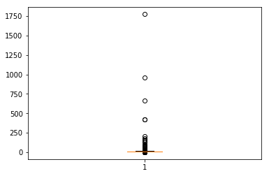

```python
plt.boxplot(df_archive.rating_numerator)
```

```python
df_archive.rating_numerator.value_counts().head(20)
```

```
12     558
11     464
10     461
13     351
9      158
8      102
7      55
14     54
5      37
6      32
3      19
4      17
1      9
2      9
420    2
0      2
15     2
75     2
80     1
20     1
Name: rating_numerator, dtype: int64
```

```
{'whiskers': [<matplotlib.lines.Line2D at 0x7f11418c3080>,
 'caps': [<matplotlib.lines.Line2D at 0x7f11418c3a20>,
 'boxes': [<matplotlib.lines.Line2D at 0x7f11418b7eb8>],
 'medians': [<matplotlib.lines.Line2D at 0x7f11418ca320>],
 'fliers': [<matplotlib.lines.Line2D at 0x7f11418ca780>],
 'means': []}
```

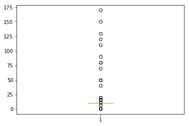

```python
plt.boxplot(df_archive.rating_denominator)
```

```python
df_archive.rating_denominator.value_counts().head(20)
```

```
10     2333
11     3
50     3
80     2
20     2
2      1
16     1
40     1
70     1
15     1
90     1
110    1
120    1
130    1
150    1
170    1
7      1
0      1
Name: rating_denominator, dtype: int64
```

Looking at the value counts in the "name" column, we can see that many are labelled as "None", and others are labelled incorrectly such as "a", "the" and "an"..these are not actual dog names and are all different variations of indicating that no name was provided

```python
df_archive.name.value_counts().head(20)
```

```
None       745
a          55
Charlie    12
Oliver     11
Cooper     11
Lucy       11
Lola       10
Penny      10
Tucker     10
Bo         9
Winston    9
the        8
Sadie      8
an         7
Toby       7
Bailey     7
Daisy      7
Buddy      7
Milo       6
Jax        6
Name: name, dtype: int64
```

```python
df_predict.head()
```

|  | tweet_id | jpg_url | img_num | p1 | p1_conf | p1_dog | p2 | p2_conf | p2_dog | p3 | p3_conf | p3_dog |
| --- | --- | --- | --- | --- | --- | --- | --- | --- | --- | --- | --- | --- |
| 0 | 666020888022790149 | https://pbs.twimg.com/media/CT4udn0WwAA0aMy.jpg | 1 | Welsh_springer_spaniel | 0.465074 | True | collie | 0.156665 | True | Shetland_sheepdog | 0.061428 | True |
| 1 | 666029285002620928 | https://pbs.twimg.com/media/CT42GRgUYAA5iDo.jpg | 1 | redbone | 0.506826 | True | miniature_pinscher | 0.074192 | True | Rhodesian_ridgeback | 0.072010 | True |
| 2 | 666033412701032449 | https://pbs.twimg.com/media/CT4521TWwAEvMyu.jpg | 1 | German_shepherd | 0.596461 | True | malinois | 0.138584 | True | bloodhound | 0.116197 | True |
| 3 | 666044226329800704 | https://pbs.twimg.com/media/CT5Dr8HUEAA-lEu.jpg | 1 | Rhodesian_ridgeback | 0.408143 | True | redbone | 0.360687 | True | miniature_pinscher | 0.222752 | True |
| 4 | 666049248165822465 | https://pbs.twimg.com/media/CT5IQmsXIAAKY4A.jpg | 1 | miniature_pinscher | 0.560311 | True | Rottweiler | 0.243682 | True | Doberman | 0.154629 | True |

Using df.info() we can see there are 2075 rows and no null values in any column. tweet_id should be datatype 'object' instead of 'int64', as it is not used for calculations

```python
df_predict.info()
```

```
<class 'pandas.core.frame.DataFrame'>
RangeIndex: 2075 entries, 0 to 2074
Data columns (total 12 columns):
tweet_id    2075 non-null int64
jpg_url     2075 non-null object
img_num     2075 non-null int64
p1          2075 non-null object
p1_conf     2075 non-null float64
p1_dog      2075 non-null bool
p2          2075 non-null object
p2_conf     2075 non-null float64
p2_dog      2075 non-null bool
p3          2075 non-null object
p3_conf     2075 non-null float64
p3_dog      2075 non-null bool
dtypes: bool(3), float64(3), int64(2), object(4)
memory usage: 152.1+ KB
```

```python
df_predict.describe()
```

|  | tweet_id | img_num | p1_conf | p2_conf | p3_conf |
| --- | --- | --- | --- | --- | --- |
| count | 2.075000e+03 | 2075.000000 | 2075.000000 | 2.075000e+03 | 2.075000e+03 |
| mean | 7.384514e+17 | 1.203855 | 0.594548 | 1.345886e-01 | 6.032417e-02 |
| std | 6.785203e+16 | 0.561875 | 0.271174 | 1.006657e-01 | 5.090593e-02 |
| min | 6.660209e+17 | 1.000000 | 0.044333 | 1.011300e-08 | 1.740170e-10 |
| 25% | 6.764835e+17 | 1.000000 | 0.364412 | 5.388625e-02 | 1.622240e-02 |
| 50% | 7.119988e+17 | 1.000000 | 0.588230 | 1.181810e-01 | 4.944380e-02 |
| 75% | 7.932034e+17 | 1.000000 | 0.843855 | 1.955655e-01 | 9.180755e-02 |
| max | 8.924206e+17 | 4.000000 | 1.000000 | 4.880140e-01 | 2.734190e-01 |

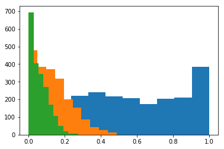

```python
plt.hist(df_predict.p1_conf)
plt.hist(df_predict.p2_conf)
plt.hist(df_predict.p3_conf)
```

```python
df_api.head()
```

|  | tweet_id | retweet_count | favorite_count | entities_media_url |
| --- | --- | --- | --- | --- |
| 0 | 892420643555336193 | 7447 | 35288 | http://pbs.twimg.com/media/DGKD1-bXoAAIAUK.jpg |
| 1 | 892177421306343426 | 5532 | 30529 | http://pbs.twimg.com/media/DGGmoV4XsAAUL6n.jpg |
| 2 | 891815181378084864 | 3660 | 22981 | http://pbs.twimg.com/media/DGBdLU1WsAANxJ9.jpg |
| 3 | 891689557279858688 | 7618 | 38570 | http://pbs.twimg.com/media/DF_q7IAWsAEuuN8.jpg |
| 4 | 891327558926688256 | 8213 | 36856 | http://pbs.twimg.com/media/DF6hr6AVYAAZ8G8.jpg |

retweet_count and favorite count are numbers, they should be datatype int64

```python
df_api.dtypes
```

```
tweet_id              object
retweet_count         object
favorite_count        object
entities_media_url    object
dtype: object
```

df.describe() does not work as expected here because the columns are all object type instead of int or float

```python
df_api.describe()
```

|  | tweet_id | retweet_count | favorite_count | entities_media_url |
| --- | --- | --- | --- | --- |
| count | 2059 | 2059 | 2059 | 2059 |
| unique | 2059 | 1561 | 1820 | 2000 |
| top | 808501579447930884 | 51 | 0 | http://pbs.twimg.com/media/CtzKC7zXEAALfSo.jpg |
| freq | 1 | 5 | 72 | 2 |

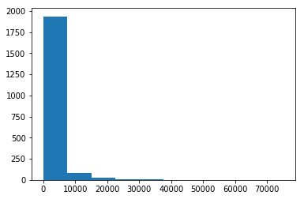

```python
plt.hist(df_api.retweet_count.astype(int))
```

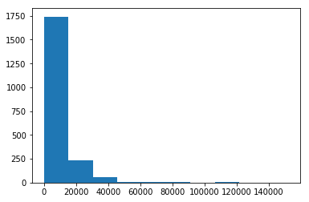

```python
plt.hist(df_api.favorite_count.astype(int))
```

### Quality Issues:

#### df_archive:

- Q1) Completeness: 78 entries are replies to other tweets rather than unique entries - these should be removed
- Q2) Completeness: 181 entries are retweets rather than unique entries - these should be removed
- Q3) Datatypes: id and all other unique identifiers should be type 'object', timestamp should be type 'datetime'
- Q4) Validity/Accuracy: In some cases, the ratings are not properly extracted from the tweet text (i.e. tweets with other numbers in the text, tweets with decimal ratings)
- Q5) Accuracy: there are a few outliers in the rating_numerator, Max = 1776
- Q6) Validity: there are invalid values in the rating_denominator, leading to unstandardized scores. Max = 170, Min = 0
- Q7) Accuracy: some dog names are inaccurate, such as 'a', 'the', 'very'...these should all be standardized as 'none'
- Q8) Consistency: There are different versions of the same dog stages that are not being captured, i.e. "Doggo" or "doggos" in addition to "doggo"

#### df_predict

- Q9) Datatypes: tweet_id should be type 'object', currently 'int64'. p1, p2, and p3 should be type 'category', currently 'object'

#### df_api

- Q10) Dataypes: retweet_count and favorite_count should be type 'int64', currently 'object'

### Tidiness Issues:

- T1) In archive table, doggo, floofer, pupper, puppo should all be under one categorical column called 'dog_stages'
- T2) In archive table, the expanded_urls column contains multiple URLs for some tweets
- T3) Data should be merged into a single dataframe, as all data are focused on the same observational unit (a tweet)

## Data Cleaning

#### Create copies of each of the dataframes:

```python
archive_clean = df_archive.copy()
predict_clean = df_predict.copy()
api_clean = df_api.copy()
```

### Cleaning the Twitter Archive Dataset

#### Q1) Completeness: 78 entries in the archive table are replies to other tweets rather than unique entries

#### Q2) Completeness: 181 entries in the archive table are retweets rather than unique entries

Define:

- Use boolean filtering to filter the data frame for rows where retween and reply id are NaN

Code:

```python
archive_clean = archive_clean[archive_clean.in_reply_to_status_id.isnull() & archive_clean.retweeted_status_id.isnull()]
```

Test:

```python
archive_clean.retweeted_status_id.value_counts()
```

```
Series([], Name: retweeted_status_id, dtype: int64)
```

- Drop these unneeded columns

```python
archive_clean = archive_clean.drop(columns=['in_reply_to_status_id','in_reply_to_user_id','source','retweeted_status_id','retweeted_status_user_id','retweeted_status_timestamp'],axis=1)
```

```python
archive_clean.head()
archive_clean.shape
```

```
(2097, 11)
```

#### Q3) Datatypes: in archive table, tweet_id and all other unique identifiers should be type 'object', timestamp should be type 'datetime**

Define

- use pd.series.astype() to change datatypes of columns

Code:

```python
archive_clean.tweet_id = archive_clean.tweet_id.astype('object')
archive_clean.timestamp = pd.to_datetime(archive_clean.timestamp)
```

Test:

```python
archive_clean.dtypes
```

```
tweet_id              object
timestamp             datetime64[ns]
text                  object
expanded_urls         object
rating_numerator      int64
rating_denominator    int64
name                  object
doggo                 object
floofer               object
pupper                object
puppo                 object
dtype: object
```

#### Q4) Accuracy: In some cases, the ratings are not properly extracted from the tweet text (i.e. tweets with other numbers in the text, tweets with decimal ratings)

#### Q5) Accuracy: there are extreme outliers in the rating_numerator, max value is 1776

#### Q6) Validity: there are rating_denominator values > 10 in tweets with more than one dog. These should be normalized.

Define

- Use regex to properly extract ratings from text using str.extract()
- Split ratings on '/' and update numerator and denominator columns using str.split()
- Normalize ratings by dividing numerators by denominators
- Remove outliers by dropping tweets with normalized ratings over a threshold (1.4)

Code:

```python
#use regex to extract more accurate ratings from tweet text and update the rating_numerator and rating_denominator columns
archive_clean['rating'] = archive_clean.text.str.extract('((?:\d+\.)?\d+\/\d{2,})',expand=True)
archive_clean['rating_numerator'],archive_clean['rating_denominator'] = archive_clean['rating'].str.split('/', 1).str

#change datatypes to int to create calculated column
archive_clean['rating_numerator'] = archive_clean['rating_numerator'].astype(float)
archive_clean['rating_denominator'] = archive_clean['rating_denominator'].astype(float)

#create a calculated field with the normalized rating score
archive_clean['rating_score'] = archive_clean['rating_numerator'] / archive_clean['rating_denominator']
archive_clean.sort_values('rating_score',ascending=False)

#drop rating_score outliers that are >1.4 or NaN
archive_clean = archive_clean[(archive_clean.rating_score <= 1.4) & archive_clean.rating_score.notnull()]

#drop the rating_numerator and rating_denominator columns
archive_clean = archive_clean.drop(columns=['rating_numerator','rating_denominator'],axis=1)
```

Test:

```python
archive_clean.head()
```

|  | tweet_id | timestamp | text | expanded_urls | name | doggo | floofer | pupper | puppo | rating | rating_score |
| --- | --- | --- | --- | --- | --- | --- | --- | --- | --- | --- | --- |
| 0 | 892420643555336193 | 2017-08-01 16:23:56 | This is Phineas. He's a mystical boy. Only ever appears in the hole of a donut. 13/10 https://t.co/MgUWQ76dJU | https://twitter.com/dog_rates/status/892420643555336193/photo/1 | Phineas | None | None | None | None | 13/10 | 1.3 |
| 1 | 892177421306343426 | 2017-08-01 00:17:27 | This is Tilly. She's just checking pup on you. Hopes you're doing ok. If not, she's available for pats, snugs, boops, the whole bit. 13/10 https://t.co/0Xxu71qeIV | https://twitter.com/dog_rates/status/892177421306343426/photo/1 | Tilly | None | None | None | None | 13/10 | 1.3 |
| 2 | 891815181378084864 | 2017-07-31 00:18:03 | This is Archie. He is a rare Norwegian Pouncing Corgo. Lives in the tall grass. You never know when one may strike. 12/10 https://t.co/wUnZnhtVJB | https://twitter.com/dog_rates/status/891815181378084864/photo/1 | Archie | None | None | None | None | 12/10 | 1.2 |
| 3 | 891689557279858688 | 2017-07-30 15:58:51 | This is Darla. She commenced a snooze mid meal. 13/10 happens to the best of us https://t.co/tD36da7qLQ | https://twitter.com/dog_rates/status/891689557279858688/photo/1 | Darla | None | None | None | None | 13/10 | 1.3 |
| 4 | 891327558926688256 | 2017-07-29 16:00:24 | This is Franklin. He would like you to stop calling him "cute." He is a very fierce shark and should be respected as such. 12/10 #BarkWeek https://t.co/AtUZn91f7f | https://twitter.com/dog_rates/status/891327558926688256/photo/1,https://twitter.com/dog_rates/status/891327558926688256/photo/1 | Franklin | None | None | None | None | 12/10 | 1.2 |

#### Q7) Accuracy: a variety of wrong dog names such as 'a', 'the', and 'very' were recorded

Define:

- isolate all the dog names that start with lowercase letters or that are 'None' (these are incorrect names)
- use pandas .loc to isolate these names with boolean, and convert them all to np.nan

Code:

```python
#isolate all the lowercase names and names that are 'None'

lowercase = archive_clean.name.str.islower()
none = archive_clean.name == 'None'
column_name = 'name'

#convert them all to NaN

archive_clean.loc[lowercase,column_name] = np.nan
archive_clean.loc[none,column_name] = np.nan
```

Test:

```python
print(archive_clean.name.value_counts().head(10)) #no more lowercase wrong names in the list
print('\nThere are', archive_clean.name.isnull().sum(),'tweets with no name')
```

```
Lucy       11
Charlie    11
Cooper     10
Oliver     10
Tucker     9
Penny      9
Winston    8
Sadie      8
Lola       8
Daisy      7
Name: name, dtype: int64

There are 706 tweets with no name
```

#### Q8) Consistency: There are Capitalized or plural versions of dog stages that are not being captured, i.e. "Doggo" or "doggos" in addition to "doggo".

Define:

- use updated regex to improve the results captured in each of the current dog stage columns (i.e. include plurals and capital letters)

Code:

```python
#improve the dog_stage capture by using regex to also grab plurals and capitalized versions
archive_clean['doggo'] = archive_clean.text.str.extract('([Dd]oggos?)',expand=True)
archive_clean['floofer'] = archive_clean.text.str.extract('([Ff]loofers?)',expand=True)
archive_clean['pupper'] = archive_clean.text.str.extract('([Pp]uppers?)',expand=True)
archive_clean['puppo'] = archive_clean.text.str.extract('([Pp]uppos?)',expand=True)

#standardize the names of the captured dog stages
vals_to_replace = {'Doggo':'doggo', 'doggos':'doggo','Floofer':'floofer','puppers':'pupper','Pupper':'pupper','puppos':'puppo','Puppo':'puppo'}
archive_clean = archive_clean.replace({'doggo':vals_to_replace}).replace({'floofer':vals_to_replace}).replace({'pupper':vals_to_replace}).replace({'puppo':vals_to_replace})
```

Test:

```python
#test to confirm that all counts have been aggregated and standardized for each column
print(archive_clean.doggo.value_counts())
print(archive_clean.floofer.value_counts())
print(archive_clean.pupper.value_counts())
print(archive_clean.puppo.value_counts())
```

```
doggo    90
Name: doggo, dtype: int64
floofer    10
Name: floofer, dtype: int64
pupper    252
Name: pupper, dtype: int64
puppo    30
Name: puppo, dtype: int64
```

#### T1) In archive table, doggo, floofer, pupper, puppo should all be under one categorical column called 'dog_stages'

Define:

- create a new column called dog_stage that concatenates everything from the other columns including tweets that mention multiple stages
- drop the original four columns (doggo, floofer, pupper, puppo) no longer needed

Code:

```python
#replace NaN values with '' so that we can concatenate the strings
archive_clean['doggo'].replace(np.nan,'',inplace=True)
archive_clean['floofer'].replace(np.nan,'',inplace=True)
archive_clean['pupper'].replace(np.nan,'',inplace=True)
archive_clean['puppo'].replace(np.nan,'',inplace=True)

#create a new column called dog_stage that concatenates everything from the four original columns
archive_clean['dog_stage'] = archive_clean.doggo + archive_clean.floofer + archive_clean.pupper + archive_clean.puppo
archive_clean['dog_stage'].unique()

#adjust the names of values using loc and boolean conditions
archive_clean.loc[archive_clean.dog_stage == 'doggopupper','dog_stage'] = 'doggo, pupper'
archive_clean.loc[archive_clean.dog_stage == 'doggopuppo','dog_stage'] = 'doggo, puppo'
archive_clean.loc[archive_clean.dog_stage == 'doggofloofer','dog_stage'] = 'doggo, floofer'
archive_clean.loc[archive_clean.dog_stage == '','dog_stage'] = np.nan

#drop the doggo, floofer, pupper, and puppo columns which are no longer needed
archive_clean = archive_clean.drop(columns=['doggo','floofer','pupper','puppo'],axis=1)

#change the type of dog_stage column to category
archive_clean['dog_stage'] = archive_clean['dog_stage'].astype('category')
```

Test:

```python
print(archive_clean.dog_stage.value_counts())
archive_clean[archive_clean.dog_stage.notnull()].head(20)
```

```
pupper            243
doggo             78
puppo             28
floofer           9
doggo, pupper     9
doggo, puppo      2
doggo, floofer    1
Name: dog_stage, dtype: int64
```

|  | tweet_id | timestamp | text | expanded_urls | name | rating | rating_score | dog_stage |
| --- | --- | --- | --- | --- | --- | --- | --- | --- |
| 9 | 890240255349198849 | 2017-07-26 15:59:51 | This is Cassie. She is a college pup. Studying international doggo communication and stick theory. 14/10 so elegant much sophisticate https://t.co/t1bfwz5S2A | https://twitter.com/dog_rates/status/890240255349198849/photo/1 | Cassie | 14/10 | 1.4 | doggo |
| 12 | 889665388333682689 | 2017-07-25 01:55:32 | Here's a puppo that seems to be on the fence about something haha no but seriously someone help her. 13/10 https://t.co/BxvuXk0UCm | https://twitter.com/dog_rates/status/889665388333682689/photo/1 | NaN | 13/10 | 1.3 | puppo |
| 14 | 889531135344209921 | 2017-07-24 17:02:04 | This is Stuart. He's sporting his favorite fanny pack. Secretly filled with bones only. 13/10 puppared puppo #BarkWeek https://t.co/y70o6h3isq | https://twitter.com/dog_rates/status/889531135344209921/photo/1 | Stuart | 13/10 | 1.3 | puppo |
| 29 | 886366144734445568 | 2017-07-15 23:25:31 | This is Roscoe. Another pupper fallen victim to spontaneous tongue ejections. Get the BlepiPen immediate. 12/10 deep breaths Roscoe https://t.co/RGE08MIJox | https://twitter.com/dog_rates/status/886366144734445568/photo/1,https://twitter.com/dog_rates/status/886366144734445568/photo/1 | Roscoe | 12/10 | 1.2 | pupper |
| 43 | 884162670584377345 | 2017-07-09 21:29:42 | Meet Yogi. He doesn't have any important dog meetings today he just enjoys looking his best at all times. 12/10 for dangerously dapper doggo https://t.co/YSI00BzTBZ | https://twitter.com/dog_rates/status/884162670584377345/photo/1 | Yogi | 12/10 | 1.2 | doggo |
| 46 | 883360690899218434 | 2017-07-07 16:22:55 | Meet Grizzwald. He may be the floofiest floofer I ever did see. Lost eyes saving a schoolbus from a volcano erpuption. 13/10 heroic as h*ck https://t.co/rf661IFEYP | https://twitter.com/dog_rates/status/883360690899218434/photo/1 | Grizzwald | 13/10 | 1.3 | floofer |
| 49 | 882762694511734784 | 2017-07-06 00:46:41 | This is Gus. He's quite the cheeky pupper. Already perfected the disinterested wink. 12/10 would let steal my girl https://t.co/D43I96SlVu | https://twitter.com/dog_rates/status/882762694511734784/photo/1 | Gus | 12/10 | 1.2 | pupper |
| 54 | 881666595344535552 | 2017-07-03 00:11:11 | This is Gary. He couldn't miss this puppertunity for a selfie. Flawless focusing skills. 13/10 would boop intensely https://t.co/7CSWCl8I6s | https://twitter.com/dog_rates/status/881666595344535552/photo/1 | Gary | 13/10 | 1.3 | pupper |
| 56 | 881536004380872706 | 2017-07-02 15:32:16 | Here is a pupper approaching maximum borkdrive. Zooming at never before seen speeds. 14/10 paw-inspiring af \n(IG: puffie_the_chow) https://t.co/ghXBIIeQZF | https://twitter.com/dog_rates/status/881536004380872706/video/1 | NaN | 14/10 | 1.4 | pupper |
| 71 | 878776093423087618 | 2017-06-25 00:45:22 | This is Snoopy. He's a proud #PrideMonthPuppo. Impeccable handwriting for not having thumbs. 13/10 would love back #PrideMonth https://t.co/lNZwgNO4gS | https://twitter.com/dog_rates/status/878776093423087618/photo/1,https://twitter.com/dog_rates/status/878776093423087618/photo/1 | Snoopy | 13/10 | 1.3 | puppo |
| 82 | 876838120628539392 | 2017-06-19 16:24:33 | This is Ginger. She's having a ruff Monday. Too many pupper things going on. H*ckin exhausting. 12/10 would snug passionately https://t.co/j211oCDRs6 | https://twitter.com/dog_rates/status/876838120628539392/photo/1,https://twitter.com/dog_rates/status/876838120628539392/photo/1 | Ginger | 12/10 | 1.2 | pupper |
| 83 | 876537666061221889 | 2017-06-18 20:30:39 | I can say with the pupmost confidence that the doggos who assisted with this search are heroic as h*ck. 14/10 for all https://t.co/8yoc1CNTsu | https://twitter.com/mpstowerham/status/876162994446753793 | NaN | 14/10 | 1.4 | doggo |
| 85 | 876120275196170240 | 2017-06-17 16:52:05 | Meet Venti, a seemingly caffeinated puppoccino. She was just informed the weekend would include walks, pats and scritches. 13/10 much excite https://t.co/ejExJFq3ek | https://twitter.com/dog_rates/status/876120275196170240/photo/1 | Venti | 13/10 | 1.3 | puppo |
| 92 | 874296783580663808 | 2017-06-12 16:06:11 | This is Jed. He may be the fanciest pupper in the game right now. Knows it too. 13/10 would sign modeling contract https://t.co/0YplNnSMEm | https://twitter.com/dog_rates/status/874296783580663808/photo/1 | Jed | 13/10 | 1.3 | pupper |
| 94 | 874012996292530176 | 2017-06-11 21:18:31 | This is Sebastian. He can't see all the colors of the rainbow, but he can see that this flag makes his human happy. 13/10 #PrideMonth puppo https://t.co/XBE0evJZ6V | https://twitter.com/dog_rates/status/874012996292530176/photo/1,https://twitter.com/dog_rates/status/874012996292530176/photo/1 | Sebastian | 13/10 | 1.3 | puppo |
| 98 | 873213775632977920 | 2017-06-09 16:22:42 | This is Sierra. She's one precious pupper. Absolute 12/10. Been in and out of ICU her whole life. Help Sierra below\n\nhttps://t.co/Xp01EU3qyD https://t.co/V5lkvrGLdQ | https://www.gofundme.com/help-my-baby-sierra-get-better,https://twitter.com/dog_rates/status/873213775632977920/photo/1,https://twitter.com/dog_rates/status/873213775632977920/photo/1 | Sierra | 12/10 | 1.2 | pupper |
| 99 | 872967104147763200 | 2017-06-09 00:02:31 | Here's a very large dog. He has a date later. Politely asked this water person to check if his breath is bad. 12/10 good to go doggo https://t.co/EMYIdoblMR | https://twitter.com/dog_rates/status/872967104147763200/photo/1,https://twitter.com/dog_rates/status/872967104147763200/photo/1 | NaN | 12/10 | 1.2 | doggo |
| 106 | 871879754684805121 | 2017-06-06 00:01:46 | Say hello to Lassie. She's celebrating #PrideMonth by being a splendid mix of astute and adorable. Proudly supupporting her owner. 13/10 https://t.co/uK6PNyeh9w | https://twitter.com/dog_rates/status/871879754684805121/photo/1,https://twitter.com/dog_rates/status/871879754684805121/photo/1 | Lassie | 13/10 | 1.3 | puppo |
| 107 | 871762521631449091 | 2017-06-05 16:15:56 | This is Rover. As part of pupper protocol he had to at least attempt to eat the plant. Confirmed not tasty. Needs peanut butter. 12/10 https://t.co/AiVljI6QCg | https://twitter.com/dog_rates/status/871762521631449091/photo/1,https://twitter.com/dog_rates/status/871762521631449091/photo/1,https://twitter.com/dog_rates/status/871762521631449091/photo/1 | Rover | 12/10 | 1.2 | pupper |
| 108 | 871515927908634625 | 2017-06-04 23:56:03 | This is Napolean. He's a Raggedy East Nicaraguan Zoom Zoom. Runs on one leg. Built for deception. No eyes. Good with kids. 12/10 great doggo https://t.co/PR7B7w1rUw | https://twitter.com/dog_rates/status/871515927908634625/photo/1,https://twitter.com/dog_rates/status/871515927908634625/photo/1 | Napolean | 12/10 | 1.2 | doggo |

#### T2) in df_archive table, the expanded_urls column contains multiple URLs for some tweets

Define:

- define and apply a function to include only one instance of the twitter url for each tweet, using the unique tweet id
- drop the expanded_urls column as this is no longer needed

Code:

```python
def update_url(row):
    return ('https://twitter.com/dog_rates/status/'+str(row['tweet_id'])+'/photo/1')

archive_clean['tweet_url'] = archive_clean.apply(update_url, axis=1)
archive_clean = archive_clean.drop(columns='expanded_urls',axis=1)
```

Test:

```python
#ensure that there is only one url for each tweet, and that it contains a unique tweet_id. Can click the links to verify paths
archive_clean.tweet_url.tail()
```

```
2351    https://twitter.com/dog_rates/status/666049248165822465/photo/1
2352    https://twitter.com/dog_rates/status/666044226329800704/photo/1
2353    https://twitter.com/dog_rates/status/666033412701032449/photo/1
2354    https://twitter.com/dog_rates/status/666029285002620928/photo/1
2355    https://twitter.com/dog_rates/status/666020888022790149/photo/1
Name: tweet_url, dtype: object
```

### Cleaning the image predictions dataset

#### Q9) Datatypes: tweet_id should be type 'object', currently 'int64'. p1, p2, and p3 should be type 'category', currently 'object'

Define:

- use astype() to convert datatypes of series'

Code:

```python
predict_clean['tweet_id'] = predict_clean['tweet_id'].astype('object')
predict_clean['p1'] = predict_clean['p1'].astype('category')
predict_clean['p2'] = predict_clean['p2'].astype('category')
predict_clean['p3'] = predict_clean['p3'].astype('category')
predict_clean['img_num'] = predict_clean['img_num'].astype('category')
```

Test:

```python
predict_clean.info()
```

```
<class 'pandas.core.frame.DataFrame'>
RangeIndex: 2075 entries, 0 to 2074
Data columns (total 12 columns):
tweet_id    2075 non-null object
jpg_url     2075 non-null object
img_num     2075 non-null category
p1          2075 non-null category
p1_conf     2075 non-null float64
p1_dog      2075 non-null bool
p2          2075 non-null category
p2_conf     2075 non-null float64
p2_dog      2075 non-null bool
p3          2075 non-null category
p3_conf     2075 non-null float64
p3_dog      2075 non-null bool
dtypes: bool(3), category(4), float64(3), object(2)
memory usage: 160.9+ KB
```

### Cleaning theTwitter API extracted dataset

#### Q10) Dataypes: retweet_count and favorite_count should be type 'int64', currently 'object'

Define:

- use astype() to convert datatypes of series'

Code:

```python
api_clean['retweet_count'] = api_clean['retweet_count'].astype('int64')
api_clean['favorite_count'] = api_clean['favorite_count'].astype('int64')
```

Test:

```python
api_clean.info()
```

```
<class 'pandas.core.frame.DataFrame'>
Int64Index: 2059 entries, 0 to 2058
Data columns (total 4 columns):
tweet_id              2059 non-null object
retweet_count         2059 non-null int64
favorite_count        2059 non-null int64
entities_media_url    2059 non-null object
dtypes: int64(2), object(2)
memory usage: 80.4+ KB
```

### Merging Datasets

#### T3) Data should be merged into one dataframe, as it is focused on the same observational unit (a tweet)

Define:

- Use pd.DataFrame.merge to merge archive_clean and api_clean on tweet_id
- Then use a second pd.DataFrame.merge to merge the resulting table to the predict_clean table on predict.tweet_id

Code:

```python
df_clean = archive_clean.merge(api_clean,how='inner',on='tweet_id').merge(predict_clean,how='inner',on='tweet_id')
```

Test:

*Note that I've used inner joins, so the total number of records in the dataset drops from 2094 to 1961. In my opinion, this is an acceptable amount of data loss to ensure completeness of the dataset.*

```python
print(df_clean.info())
```

```
<class 'pandas.core.frame.DataFrame'>
Int64Index: 1961 entries, 0 to 1960
Data columns (total 22 columns):
tweet_id              1961 non-null object
timestamp             1961 non-null datetime64[ns]
text                  1961 non-null object
name                  1340 non-null object
rating                1961 non-null object
rating_score          1961 non-null float64
dog_stage             334 non-null category
tweet_url             1961 non-null object
retweet_count         1961 non-null int64
favorite_count        1961 non-null int64
entities_media_url    1961 non-null object
jpg_url               1961 non-null object
img_num               1961 non-null category
p1                    1961 non-null category
p1_conf               1961 non-null float64
p1_dog                1961 non-null bool
p2                    1961 non-null category
p2_conf               1961 non-null float64
p2_dog                1961 non-null bool
p3                    1961 non-null category
p3_conf               1961 non-null float64
p3_dog                1961 non-null bool
dtypes: bool(3), category(5), datetime64[ns](1), float64(4), int64(2), object(7)
memory usage: 310.7+ KB
None
```

## Store Clean Data

```python
df_clean.to_csv('twitter_archive_master.csv',index=False)
```

## Data Analysis & Visualizations

### Questions I will investigate using the newly cleaned dataset:

#### Insight Area 1: Relationship Between Rating Scores and Audience Popularity

- Which tweets get the highest number of retweets and favorites?
- Is there a difference in mean rating between the most popular tweets sub-sample and the entire sample?
- What are the correlations between 1) rating score vs number of retweets, and 2) rating score vs # of favorites?

#### Insight Area 2: Image Classifications:

- Which breeds of dogs were identified most often by the classification algorithm?
- Which breeds of dog does the classification algorithm identify with the highest confidence?
- What are the most common pairs of predictions by the model?

#### Insight Area 3: Changes Over Time

- How many tweets are being posted each month?
- How are the rating scores trending over time - Are the reviewers getting tougher or more generous?

### Insight Area 1: Relationship Between Rating Scores and Audience Popularity

#### Which tweets get the highest number of retweets and favorites?

```python
#new dfs for top 100 most retweeted and top 100 most favorited tweets
most_retweeted = df_clean.sort_values('retweet_count',ascending=False).head(100)
most_favorited = df_clean.sort_values('favorite_count',ascending=False).head(100)
```

#### What is the single most retweeted tweet? Is it also the most favorited tweet?

```python
most_retweeted.head(1)
```

|  | tweet_id | timestamp | text | name | rating | rating_score | dog_stage | tweet_url | retweet_count | favorite_count | ... | img_num | p1 | p1_conf | p1_dog | p2 | p2_conf | p2_dog | p3 | p3_conf | p3_dog |
| --- | --- | --- | --- | --- | --- | --- | --- | --- | --- | --- | --- | --- | --- | --- | --- | --- | --- | --- | --- | --- | --- |
| 761 | 744234799360020481 | 2016-06-18 18:26:18 | Here's a doggo realizing you can stand in a pool. 13/10 enlightened af (vid by Tina Conrad) https://t.co/7wE9LTEXC4 | NaN | 13/10 | 1.3 | doggo | https://twitter.com/dog_rates/status/744234799360020481/photo/1 | 75173 | 152086 | ... | 1 | Labrador_retriever | 0.825333 | True | ice_bear | 0.044681 | False | whippet | 0.018442 | True |

1 rows × 22 columns

```python
most_favorited.head(1)
```

|  | tweet_id | timestamp | text | name | rating | rating_score | dog_stage | tweet_url | retweet_count | favorite_count | ... | img_num | p1 | p1_conf | p1_dog | p2 | p2_conf | p2_dog | p3 | p3_conf | p3_dog |
| --- | --- | --- | --- | --- | --- | --- | --- | --- | --- | --- | --- | --- | --- | --- | --- | --- | --- | --- | --- | --- | --- |
| 761 | 744234799360020481 | 2016-06-18 18:26:18 | Here's a doggo realizing you can stand in a pool. 13/10 enlightened af (vid by Tina Conrad) https://t.co/7wE9LTEXC4 | NaN | 13/10 | 1.3 | doggo | https://twitter.com/dog_rates/status/744234799360020481/photo/1 | 75173 | 152086 | ... | 1 | Labrador_retriever | 0.825333 | True | ice_bear | 0.044681 | False | whippet | 0.018442 | True |

1 rows × 22 columns

*Answer: YES! This tweet of a doggo standing in a pool was both the most retweeted and most favorited tweet in the dataset.*

#### Is there a difference in mean rating between the most popular tweet sub-samples and the overall sample of tweets?

Overall sample mean rating:

```python
sample_mean = df_clean.rating_score.mean()
print(sample_mean)
```

```
1.05310175699
```

'Top 100 most retweeted' mean rating & difference from overall:

```python
most_rt_mean = most_retweeted.rating_score.mean()
print(most_rt_mean)
print(most_rt_mean - sample_mean)
```

```
1.24104545455
0.187943697557
```

'Top 100 most favorited' mean rating & difference from overall:

```python
most_fav_mean = most_favorited.rating_score.mean()
print(most_fav_mean)
print(most_fav_mean - sample_mean)
```

```
1.25904545455
0.205943697557
```

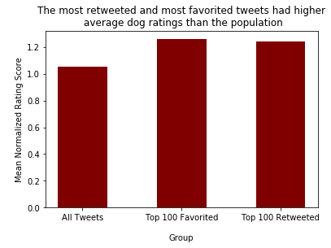

```python
plt.bar(['All Tweets', 'Top 100 Retweeted', 'Top 100 Favorited'],[sample_mean, most_rt_mean, most_fav_mean],width=0.5,color='maroon')
plt.xlabel('\nGroup')
plt.ylabel('\nMean Normalized Rating Score')
plt.title('The most retweeted and most favorited tweets had higher\n average dog ratings than the population')
plt.show()
```

*We can see that the most retweeted and most favorited tweets in the sample had received on average a 0.2 higher rating score from the WeRateDogs Twitter account. For context, this is equivalent to an average rating of **12.4/10** (top 100 most retweeted) and **12.5/10** (top 100 most favorited) versus **10.5/10** (entire sample)*

#### What are the correlations between 1) rating score vs. number of retweets, and 2) rating score vs. number of favorites?

```python
correlation = df_clean.corr()
correlation['rating_score'].sort_values(ascending=False)
```

```
rating_score      1.000000
favorite_count    0.389606
retweet_count     0.291593
p1_dog            0.286893
p2_dog            0.244395
p3_dog            0.228257
p1_conf           0.104244
p2_conf           0.005027
p3_conf          -0.029471
Name: rating_score, dtype: float64
```

```
Text(0.5,1,'Heatmap of Correlations Between Numerical Variables\n')
```

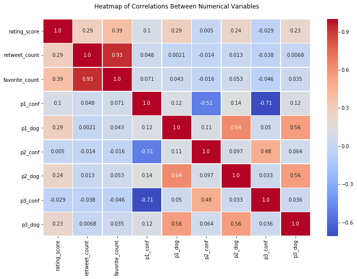

```python
fig, ax = plt.subplots(figsize=(12, 8))
ax = sns.heatmap(correlation, cmap='coolwarm',annot=True, fmt='.2',linewidths=.5)
ax.set_title('Heatmap of Correlations Between Numerical Variables\n')
```

*From this we can see that there is a moderate positive correlation between a tweet's rating score and the number of favorites it receives (0.390) and a slightly milder positive correlation with the number of retweets it received (0.292)*

*We can also see from this table that an image being classified as a dog correlated positively with rating. It's too bad for all the other creatures and things posted in photos, but this account is impartial to dogs!*

### Insight Area 2: Image Classifications:

#### Which breeds of dogs (or other images) were identified most often by the classification algorithm (first prediction only)?

```python
df_clean.groupby('p1').tweet_id.count().sort_values(ascending=False).head(10)
```

```
p1
golden_retriever      136
Labrador_retriever    92
Pembroke              88
Chihuahua             78
pug                   54
chow                  41
Samoyed               39
Pomeranian            38
toy_poodle            36
malamute              29
Name: tweet_id, dtype: int64
```

#### Which breeds of dogs (or other images) identified by the classification algorithm (first prediction only) received the highest average ratings from WeRateDogs?

```python
df_clean.groupby('p1').rating_score.mean().sort_values(ascending=False).head(10)
```

```
p1
pedestal            1.4
prison              1.4
pole                1.4
limousine           1.4
laptop              1.4
military_uniform    1.4
bannister           1.3
barbell             1.3
fountain            1.3
snowmobile          1.3
Name: rating_score, dtype: float64
```

*The fact that all of these are non-dogs is a bit of a surprising result given the correlations we saw from the previous insight, and my guess is that it's due to 1) the sample size (the means are suspiciously clean numbers), and/or 2) the accuracy of the classification algorithm. To satisfy my curiosity, I looked up the image classified as 'pedestal' and below is the result:*

[figure not shown]

I mean it wasn't totally wrong...

- Source: https://pbs.twimg.com/media/CwWVe_3WEAAHAvx.jpg

```python
df_clean[df_clean.p1 == 'pedestal'].jpg_url
```

```
446    https://pbs.twimg.com/media/CwWVe_3WEAAHAvx.jpg
Name: jpg_url, dtype: object
```

Now for the top 10 actual dog breeds:

```python
top_10_breeds = df_clean[df_clean.p1_dog == True].groupby('p1').rating_score.mean().sort_values(ascending=False).head(10)
top_10_breeds = top_10_breeds.reset_index().rename(columns={'p1': 'dog_breed'})
top_10_breeds
```

|  | dog_breed | rating_score |
| --- | --- | --- |
| 0 | Saluki | 1.250000 |
| 1 | briard | 1.233333 |
| 2 | Tibetan_mastiff | 1.225000 |
| 3 | Border_terrier | 1.214286 |
| 4 | standard_schnauzer | 1.200000 |
| 5 | silky_terrier | 1.200000 |
| 6 | Eskimo_dog | 1.177778 |
| 7 | Gordon_setter | 1.175000 |
| 8 | Irish_setter | 1.175000 |
| 9 | Samoyed | 1.174359 |

#### Which breed of dog (or other object) does the classification algorithm identify with the highest confidence?

First let's include all predictions:

```python
highest_confidence = df_clean.groupby('p1').p1_conf.mean().sort_values(ascending=False).head(10)
highest_confidence.reset_index().rename(columns={'p1':'image_prediction','p1_conf':'confidence_level'})
```

|  | image_prediction | confidence_level |
| --- | --- | --- |
| 0 | ping-pong_ball | 0.999945 |
| 1 | peacock | 0.999924 |
| 2 | school_bus | 0.999833 |
| 3 | bib | 0.998814 |
| 4 | slug | 0.998075 |
| 5 | zebra | 0.997673 |
| 6 | fountain | 0.997509 |
| 7 | china_cabinet | 0.996031 |
| 8 | flamingo | 0.992710 |
| 9 | fiddler_crab | 0.992069 |

[output not shown]

Sources:

- https://pbs.twimg.com/media/CU3FbQgVAAACdCQ.jpg.
- https://pbs.twimg.com/media/CU3qHNTWsAApGr0.jpg

Now applying a filter to only include predictions that are dog breeds:

```python
df_clean[df_clean.p1_dog == True].groupby('p1').p1_conf.mean().sort_values(ascending=False).head(10)
```

```
p1
komondor                0.972531
clumber                 0.946718
Brittany_spaniel        0.874545
keeshond                0.844431
bull_mastiff            0.815618
Bernese_mountain_dog    0.801816
French_bulldog          0.777413
pug                     0.759223
Pomeranian              0.743606
Samoyed                 0.740719
Name: p1_conf, dtype: float64
```

*Komondor is the breed of dog that the algorithm is most confident classifying, with a first prediction confidence of 97.2%*

#### What are the most common pairs of first and second predictions made by the classifier model?

```python
df_clean.groupby(['p1','p2']).tweet_id.count().sort_values(ascending=False).reset_index().head(10)
```

|  | p1 | p2 | tweet_id |
| --- | --- | --- | --- |
| 0 | golden_retriever | Labrador_retriever | 63 |
| 1 | Pembroke | Cardigan | 59 |
| 2 | Labrador_retriever | golden_retriever | 30 |
| 3 | toy_poodle | miniature_poodle | 25 |
| 4 | pug | French_bulldog | 18 |
| 5 | golden_retriever | cocker_spaniel | 17 |
| 6 | malamute | Siberian_husky | 17 |
| 7 | Labrador_retriever | Chesapeake_Bay_retriever | 16 |
| 8 | Siberian_husky | Eskimo_dog | 14 |
| 9 | Eskimo_dog | Siberian_husky | 13 |

*The algorithm sees similarities between these breeds of dogs. Golden Retriever and Labrador Retriever are the most common pair of predictions that the algorithm makes*

### Insight Area 3: Changes Over Time

```python
#create a new dataframe with timestamp as index and use df.resample to group
tweet_dates = df_clean.set_index('timestamp')
```

#### How many tweets are being posted each month?

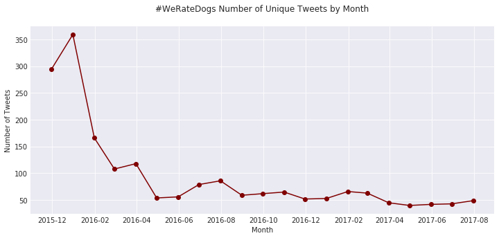

```python
# Number of tweets made by the account. Drop August 2017 as it is an incomplete month
tweets_per_month = tweet_dates.resample('M').tweet_id.count()
tweets_per_month = tweets_per_month.drop(pd.Timestamp('2017-08-31'))

#plot that as a line chart
sns.set_style('darkgrid')
fig, ax = plt.subplots(figsize=(12, 5))

ax.plot(tweets_per_month, marker='o',color='maroon')
ax.set_title('#WeRateDogs Number of Unique Tweets by Month\n')
ax.set_xlabel('Month')
ax.set_ylabel('Number of Tweets')

plt.savefig('monthly_tweets.jpg')
plt.show()
```

*After peaking at over 350 tweets in January 2016, the activity levels dropped and have since held steady at around 50 tweets per month.*

#### How are the assigned rating scores trending over time? Are the reviewers getting tougher or more generous?

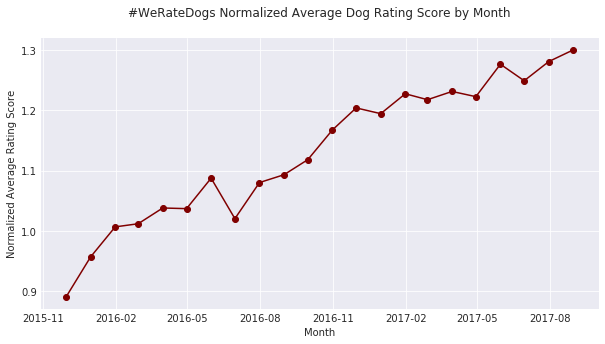

```python
#average rating score by month
avg_monthly_ratings = tweet_dates.resample('M').rating_score.mean()

sns.set_style('darkgrid')
fig, ax = plt.subplots(figsize=(10, 5))

ax.plot(avg_monthly_ratings,color='maroon', marker='o')
ax.set_title('#WeRateDogs Normalized Average Dog Rating Score by Month\n')
ax.set_xlabel('Month')
ax.set_ylabel('Normalized Average Rating Score')

plt.savefig('monthly_avg_rating.jpg')
plt.show()
```

*The WeRateDogs staff are getting more generous with their rating scores over time, with the average score approaching 13/10 in summer 2017, compared to just under 9/10 at the end of 2015.*

*This may also help explain the positive correlations between rating scores-retweets and rating_scores-favorites. The account has gained many followers over time, meaning the more recent tweets (which also happen to be rated higher) will have more retweets and favorites. This assumption can be validated in the plot below that analyzes the mean numbers of retweets and favorites per month. For a more in-depth analysis, I could also go back and pull the WeRateDogs follower numbers over time from the Twitter API.*

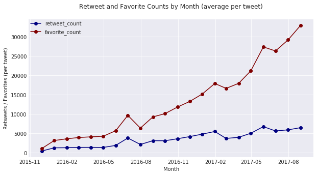

```python
avg_monthly_retweets = tweet_dates.resample('M').retweet_count.mean()
avg_monthly_favorites = tweet_dates.resample('M').favorite_count.mean()

sns.set_style('darkgrid')
fig, ax = plt.subplots(figsize=(10, 5))

ax.plot(avg_monthly_retweets,color='navy', marker='o')
ax.plot(avg_monthly_favorites,color='maroon', marker='o')
ax.set_title('Retweet and Favorite Counts by Month (average per tweet)\n')
ax.set_xlabel('Month')
ax.set_ylabel('Retweets / Favorites (per tweet)')
ax.legend(borderaxespad=0)

plt.savefig('monthly_avg_rating.jpg')
plt.show()
```

### Wordcloud Visualization:

#### A summary of the most common words across the text of all WeRateDogs tweets between November 2015 and August 2017

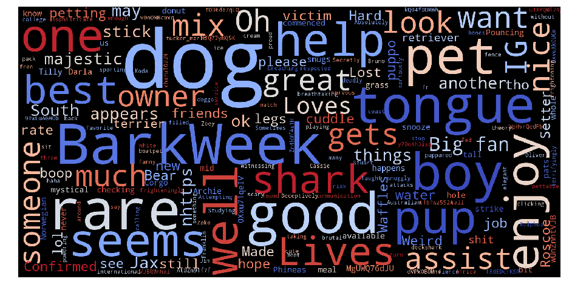

```python
from wordcloud import WordCloud, STOPWORDS
import matplotlib.pyplot as plt
stopwords = set(STOPWORDS)
words = ['https','co','ckin','af']
for word in words:
    stopwords.add(word)
def show_wordcloud(data, title = None):
    wordcloud = WordCloud(
        background_color='black',
        stopwords=stopwords,
        colormap='coolwarm',
        max_words=200,
        max_font_size=60,
        scale=4,
        random_state=1 # chosen at random by flipping a coin; it was heads
    ).generate(str(data))
    fig = plt.figure(1, figsize=(16, 16))
    plt.axis('off')
    if title:
        fig.suptitle(title, fontsize=20)
        fig.subplots_adjust(top=2.3)
    plt.imshow(wordcloud)
    plt.savefig('wordcloud.jpg')
    plt.show()
# Pass the required data in below function
show_wordcloud(df_clean['text'])
```

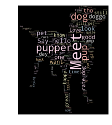

```python
from wordcloud import WordCloud, STOPWORDS
from PIL import Image
# Concatenate all text from the `text` field
text = df_clean.loc[:, 'text'].str.cat(others=None, sep=' ')
# Read the mask image
# ref: https://openclipart.org/tags/dog%20silhouette
dog_mask = np.array(Image.open('dog_silhouette.jpg'))
# Words to exclude from word cloud
stopwords = set(STOPWORDS)
words = ['https', 'damn','co','ckin','af']
for word in words:
    stopwords.add(word)
# Instantiate word cloud object
wc = WordCloud(background_color='black', max_words=200, mask=dog_mask, colormap='Pastel1',stopwords=stopwords,
              width=1280, height=960)
# Generate word cloud
wc.generate(text)
# Show word cloud
plt.imshow(wc, interpolation='bilinear')
plt.axis('off')
plt.savefig('dog_wordcloud.jpg')
plt.figure()
plt.show()
```

## Conclusions

*In this project, I gathered data on the WeRateDogs Twitter account from three different sources, including a .csv tweet archive file, a .tsv image predictions file hosted on a web server, and a JSON file generated from querying the Twitter API using tweepy. The next step was to assess the data for quality and tidiness, identifying 10 Quality issues and 3 Tidiness issues to be cleaned. I then programmatically cleaned the datasets using python functionalities in the pandas, numpy and regex libraries before merging them into one final clean dataframe. Finally, I used the newly clean data to uncover a handful of insights and visualizations around the WeRateDogs tweet data.*

*Overall, it was a good learning experience that exposed me to a handful of new capabilities such as gathering data from an API and using regex to extract or manipulate text. It also provided lots of practice with numpy and pandas, which I am becoming increasingly proficient in with each project.*

```python
from subprocess import call
call(['python', '-m', 'nbconvert', 'wrangle_act.ipynb'])
```

```
0
```